# Project Business Statistics: E-news Express

**Marks: 60**

## Define Problem Statement and Objectives

To remain competitive in the digital news space E-news Express has designed a new landing page to attract new subscribers after seeing a decline in engagement recently. We need to analyze the effectiveness of the new landing page for gaining new subscribers. This includes analyzing how much time is spent on the old landing page vs new landing page and the conversion rate of users. We also need to understand how language impacts the conversion rate and the time spent on the new landing page.

## Import all the necessary libraries

```python
#import the important packages
import pandas as pd #library used for data manipulation and analysis
import numpy as np # library used for working with arrays.
import matplotlib.pyplot as plt # library for plots and visualisations
import seaborn as sns # library for visualisations
%matplotlib inline

import scipy.stats as stats # this library contains a large number of probability distributions as well as a growing library of statistical functions.
```

## Reading the Data into a DataFrame

```python
#read in the dataset
df = pd.read_csv('abtest.csv')
```

## Explore the dataset and extract insights using Exploratory Data Analysis

- Data Overview
  - Viewing the first and last few rows of the dataset
  - Checking the shape of the dataset
  - Getting the statistical summary for the variables
- Check for missing values
- Check for duplicates

```python
#view the first 5 rows
df.head()
```

|  | user_id | group | landing_page | time_spent_on_the_page | converted | language_preferred |
| --- | --- | --- | --- | --- | --- | --- |
| 0 | 546592 | control | old | 3.48 | no | Spanish |
| 1 | 546468 | treatment | new | 7.13 | yes | English |
| 2 | 546462 | treatment | new | 4.40 | no | Spanish |
| 3 | 546567 | control | old | 3.02 | no | French |
| 4 | 546459 | treatment | new | 4.75 | yes | Spanish |

```python
#view the last 5 rows
df.tail()
```

|  | user_id | group | landing_page | time_spent_on_the_page | converted | language_preferred |
| --- | --- | --- | --- | --- | --- | --- |
| 95 | 546446 | treatment | new | 5.15 | no | Spanish |
| 96 | 546544 | control | old | 6.52 | yes | English |
| 97 | 546472 | treatment | new | 7.07 | yes | Spanish |
| 98 | 546481 | treatment | new | 6.20 | yes | Spanish |
| 99 | 546483 | treatment | new | 5.86 | yes | English |

```python
# Use info() to print a concise summary of the DataFrame
df.info()
```

```
<class 'pandas.core.frame.DataFrame'>
RangeIndex: 100 entries, 0 to 99
Data columns (total 6 columns):
 #   Column                  Non-Null Count  Dtype
---  ------                  --------------  -----
 0   user_id                 100 non-null    int64
 1   group                   100 non-null    object
 2   landing_page            100 non-null    object
 3   time_spent_on_the_page  100 non-null    float64
 4   converted               100 non-null    object
 5   language_preferred      100 non-null    object
dtypes: float64(1), int64(1), object(4)
memory usage: 4.8+ KB
```

```python
#use the shape function to print the rows & columns present in the data
print("There are", df.shape[0], 'rows and', df.shape[1], "columns.")
```

```
There are 100 rows and 6 columns.
```

```python
#check the numerial analysis of the time_spent_on_the_page
df.describe().T
```

|  | count | mean | std | min | 25% | 50% | 75% | max |
| --- | --- | --- | --- | --- | --- | --- | --- | --- |
| user_id | 100.0 | 546517.0000 | 52.295779 | 546443.00 | 546467.75 | 546492.500 | 546567.2500 | 546592.00 |
| time_spent_on_the_page | 100.0 | 5.3778 | 2.378166 | 0.19 | 3.88 | 5.415 | 7.0225 | 10.71 |

```python
#check for missing or null values
df.isnull().sum()
```

```
user_id                   0
group                     0
landing_page              0
time_spent_on_the_page    0
converted                 0
language_preferred        0
dtype: int64
```

```python
# Making a list of all categorical variables
cat_cols =  ['group','landing_page','converted','language_preferred']

# Printing the count of unique categorical levels in each column
for column in cat_cols:
    print(df[column].value_counts())
```

```
control      50
treatment    50
Name: group, dtype: int64
old    50
new    50
Name: landing_page, dtype: int64
yes    54
no     46
Name: converted, dtype: int64
Spanish    34
French     34
English    32
Name: language_preferred, dtype: int64
```

### Univariate Analysis

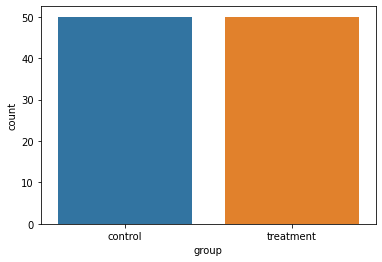

```python
cat_cols =  ['group','landing_page','time_spent_on_the_page','converted','language_preferred']
sns.countplot(data=df,x='group')
plt.show()
```

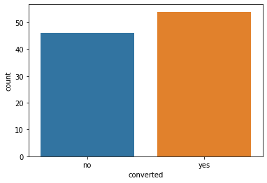

```python
sns.countplot(data=df,x='converted')
plt.show()
```

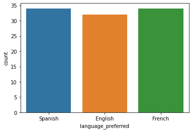

```python
sns.countplot(data=df,x='language_preferred')
plt.show()
```

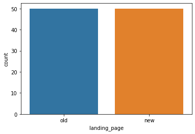

```python
sns.countplot(data=df,x='landing_page')
plt.show()
```

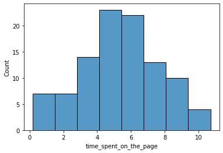

```python
sns.histplot(data=df,x='time_spent_on_the_page')
plt.show()
```

### Bivariate Analysis

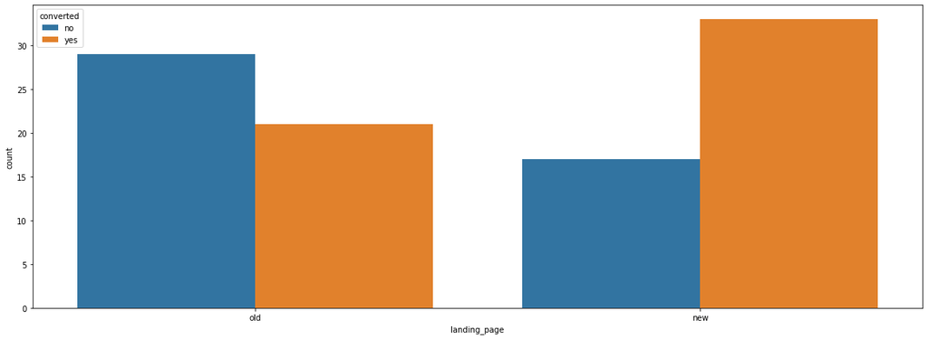

```python
plt.figure(figsize=(20,7))
sns.countplot(data=df, x='landing_page', hue='converted');
```

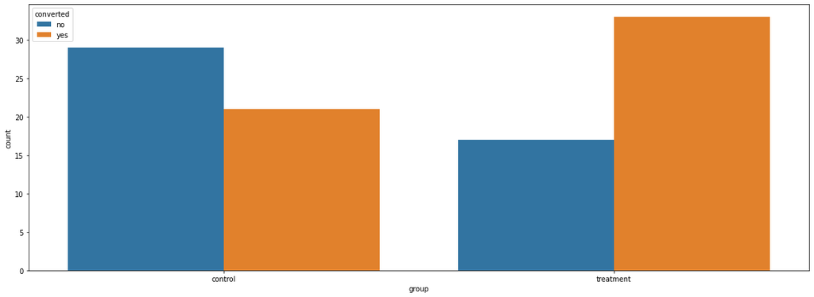

```python
plt.figure(figsize=(20,7))
sns.countplot(data=df, x='group', hue='converted');
```

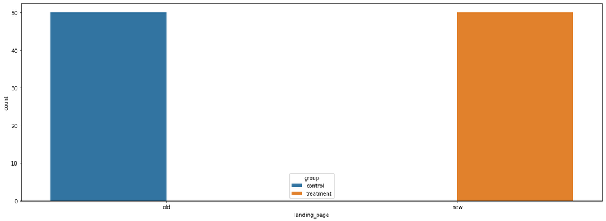

```python
plt.figure(figsize=(20,7))
sns.countplot(data=df, x='landing_page', hue='group');
```

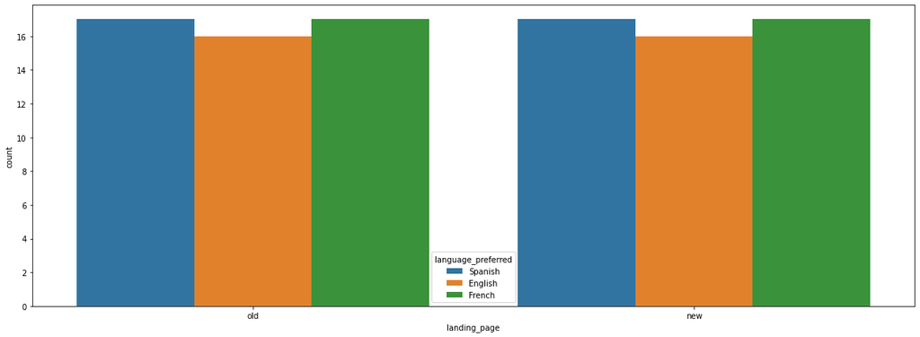

```python
plt.figure(figsize=(20,7))
sns.countplot(data=df, x='landing_page', hue='language_preferred');
```

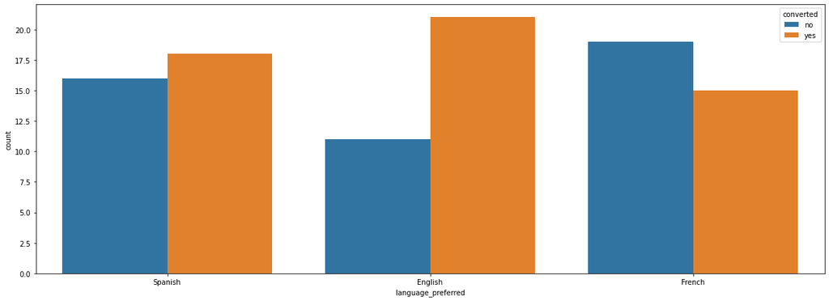

```python
plt.figure(figsize=(20,7))
sns.countplot(data=df, x='language_preferred', hue='converted');
```

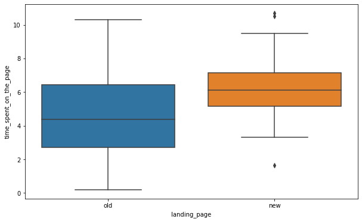

```python
plt.figure(figsize=(10,6))
sns.boxplot(data=df,x='landing_page',y='time_spent_on_the_page')
plt.show()
```

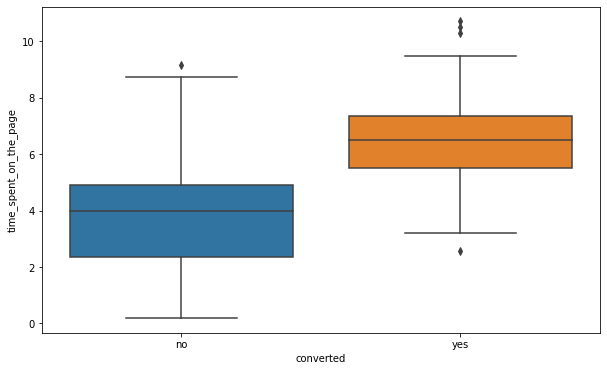

```python
plt.figure(figsize=(10,6))
sns.boxplot(data=df,x='converted',y='time_spent_on_the_page')
plt.show()
```

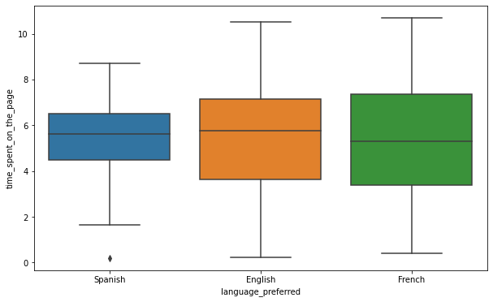

```python
plt.figure(figsize=(10,6))
sns.boxplot(data=df,x='language_preferred',y='time_spent_on_the_page')
plt.show()
```

## 1. Do the users spend more time on the new landing page than the existing landing page?

```python
#calculate the average time spent by grouping based on landing page
avg_time_spent = df.groupby(['landing_page']).mean()[['time_spent_on_the_page']].reset_index()
avg_time_spent
```

|  | landing_page | time_spent_on_the_page |
| --- | --- | --- |
| 0 | new | 6.2232 |
| 1 | old | 4.5324 |

### Perform Visual Analysis

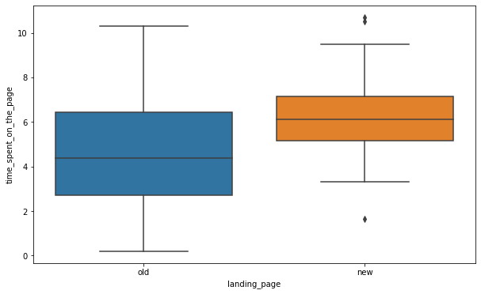

```python
plt.figure(figsize=(10,6))
sns.boxplot(data=df,x='landing_page',y='time_spent_on_the_page')
plt.show()
```

### Step 1: Define the null and alternate hypotheses

𝐻0 : Users spend less time or the same time on the new landing page than the old landing page

𝐻𝑎 : Users spend more time on the new landing page than the old landing page

### Step 2: Select Appropriate test

the sample means from 2 independent populations when the standard deviations are unknown we need Two independent sample t-test

### Step 3: Decide the significance level

The problem statement gives us a α = 0.05

### Step 4: Collect and prepare data

```python
#create data frames based on landing page
time_spent_new = df[df['landing_page'] == 'new']['time_spent_on_the_page']
time_spent_old = df[df['landing_page'] == 'old']['time_spent_on_the_page']
```

```python
#calculate the standard deviation based on landing page
print('The sample standard deviation of the time spent on the new page is:', round(time_spent_new.std(),2))
print('The sample standard deviation of the time spent on the old page is:', round(time_spent_old.std(),2))
```

```
The sample standard deviation of the time spent on the new page is: 1.82
The sample standard deviation of the time spent on the old page is: 2.58
```

```python
# Making a list of all categorical variables
cat_cols =  ['group','landing_page','converted','language_preferred']

# Printing the count of unique categorical levels in each column
for column in cat_cols:
    print(df[column].value_counts())
```

```
control      50
treatment    50
Name: group, dtype: int64
old    50
new    50
Name: landing_page, dtype: int64
yes    54
no     46
Name: converted, dtype: int64
Spanish    34
French     34
English    32
Name: language_preferred, dtype: int64
```

### Step 5: Calculate the p-value

```python
#import the required functions
from scipy.stats import ttest_ind

# find the p-value
test_stat, p_value = ttest_ind(time_spent_new, time_spent_old, equal_var = True, alternative = 'two-sided')
print('The p-value is ' + str(p_value))
```

```
The p-value is 0.000263224705619001
```

### Step 6: Compare the p-value with $\alpha$

```python
# print the conclusion based on p-value
if p_value < 0.05:
    print(f'As the p-value {p_value} is less than the level of significance, we reject the null hypothesis.')
else:
    print(f'As the p-value {p_value} is greater than the level of significance, we fail to reject the null hypothesis.')
```

```
As the p-value 0.000263224705619001 is less than the level of significance, we reject the null hypothesis.
```